# Practical Machine Learning Project

## Background

Using devices such as Jawbone Up, Nike FuelBand, and Fitbit it is now possible to collect a large amount of data about personal activity relatively inexpensively. These type of devices are part of the quantified self movement – a group of enthusiasts who take measurements about themselves regularly to improve their health, to find patterns in their behavior, or because they are tech geeks. One thing that people regularly do is quantify how much of a particular activity they do, but they rarely quantify how well they do it.

In this project, the participants were instructed to use data from accelerometers on the belt, forearm, arm, and dumbell of 6 participants. They were asked to perform barbell lifts correctly and incorrectly in 5 different ways. The goal of this project is to predict the manner in which they did the exercise. This is the “classe” variable in the training set.

## Data

The data for this project is provided by Groupware@LES, in their [Human Activity Report](http://groupware.les.inf.puc-rio.br/har).

The training dataset for this project are available here:

https://d396qusza40orc.cloudfront.net/predmachlearn/pml-training.csv

The test dataset are available here:

https://d396qusza40orc.cloudfront.net/predmachlearn/pml-testing.csv

#### Loading Data

```r
trainingset <- read.csv('./dataset/pml-training.csv', na.strings=c('','NA','#DIV/0!'))

predictors <- colnames(trainingset)
predictors # all variables / columns
```

```
##   [1] "X"                        "user_name"
##   [3] "raw_timestamp_part_1"     "raw_timestamp_part_2"
##   [5] "cvtd_timestamp"           "new_window"
##   [7] "num_window"               "roll_belt"
##   [9] "pitch_belt"               "yaw_belt"
##  [11] "total_accel_belt"         "kurtosis_roll_belt"
##  [13] "kurtosis_picth_belt"      "kurtosis_yaw_belt"
##  [15] "skewness_roll_belt"       "skewness_roll_belt.1"
##  [17] "skewness_yaw_belt"        "max_roll_belt"
##  [19] "max_picth_belt"           "max_yaw_belt"
##  [21] "min_roll_belt"            "min_pitch_belt"
##  [23] "min_yaw_belt"             "amplitude_roll_belt"
##  [25] "amplitude_pitch_belt"     "amplitude_yaw_belt"
##  [27] "var_total_accel_belt"     "avg_roll_belt"
##  [29] "stddev_roll_belt"         "var_roll_belt"
```

[output cut: 65 more lines]

#### Loading Libraries

```r
library(caret)
library(rattle)
set.seed(1001)
```

## Data Preparation

In data preparation, we split the **training dataset** into `.train` and `.test` for evaluating the model and estimate out of sample error later on. We also clean the data in order to narrow down the predictors.

##### 1. Data Partitioning

```r
# Data Partitioning
inTrain <- createDataPartition(trainingset$classe, p=.75, list=FALSE)
trainingset.train <- trainingset[ inTrain, ]; dim(trainingset.train)
trainingset.test  <- trainingset[-inTrain, ]; dim(trainingset.test)
```

```
## [1] 14718   160
## [1] 4904  160
```

##### 2. Remove Non-Predictors

We remove variables that we judged as non-predictors, i.e. variables that are judged as non consequential to the variable of interest.

```r
# Remove all non-predictors as judged:
# row index, user name, timestamp(s)
trainingset.train <- trainingset.train[, -c(1:5)]
```

##### 2. Remove NA

```r
# Function to calculate NA proportion
na.prop <- function(x) { return( sum(is.na(x))/length(x) ) }

# Find columns with NA more than 50% (my threshold)
na.vars <- apply(trainingset.train, 2, na.prop) > 0.5

# Get all the column names above NA threshold of 50%
column.names <- names(na.vars)
na.columns   <- column.names[na.vars]

# Remove the NZV columns from the predictors
na.excluded <- names(trainingset.train) %in% na.columns
trainingset.train <- trainingset.train[!na.excluded]
dim(trainingset.train)
```

```
## [1] 14718    55
```

##### 3. Remove Near Zero Variables (NZV)

```r
# Calculate Near Zero Vars (NZV)
nzv.vars <- nearZeroVar(trainingset.train, saveMetrics=TRUE)

# Get all the column names of NZV
column.names <- row.names(nzv.vars)
nzv.columns  <- column.names[nzv.vars$nzv]

# Remove the NZV columns from the predictors
nzv.excluded <- names(trainingset.train) %in% nzv.columns
trainingset.train <- trainingset.train[!nzv.excluded]
dim(trainingset.train)
```

```
## [1] 14718    54
```

## Model Training

We choose **Random Forest** model after comparison with few other models (one comparison model, i.e. Decision Tree, is shown in Appendix C). The model is used with **Repeated Cross Validation** using default **10-fold** value.

```r
# K-fold Cross Validation, default = 10-fold
ctrl <- trainControl(method='repeatedcv', repeats=3)

# Training with Random Forest Model
model.rf <- train(classe ~ . ,
                  data=trainingset.train,
                  method='rf',
                  ntree=100,
                  trControl=ctrl)
model.rf$finalModel # training result
```

```
##
## Call:
##  randomForest(x = x, y = y, ntree = 100, mtry = param$mtry)
##                Type of random forest: classification
##                      Number of trees: 100
## No. of variables tried at each split: 27
##
##         OOB estimate of  error rate: 0.24%
## Confusion matrix:
##      A    B    C    D    E  class.error
## A 4184    1    0    0    0 0.0002389486
## B    6 2838    4    0    0 0.0035112360
## C    0    5 2562    0    0 0.0019477990
## D    0    1    7 2403    1 0.0037313433
## E    0    2    0    9 2695 0.0040650407
```

## Prediction Using `.test` Dataset

##### Prediction

```r
# Apply transformations (i.e. cleaning of data) to trainingset.test
trainingset.test <- trainingset.test[, names(trainingset.train)]

# Prediction of trainingset.test dataset
predict.rf <- predict(model.rf, newdata=trainingset.test)
cm.rf <- confusionMatrix(predict.rf, trainingset.test$classe)
cm.rf  # prediction result
```

```
## Confusion Matrix and Statistics
##
##           Reference
## Prediction    A    B    C    D    E
##          A 1394    2    0    0    0
##          B    1  946    1    0    0
##          C    0    0  854    1    0
##          D    0    1    0  803    0
##          E    0    0    0    0  901
##
## Overall Statistics
##
##                Accuracy : 0.9988
##                  95% CI : (0.9973, 0.9996)
##     No Information Rate : 0.2845
##     P-Value [Acc > NIR] : < 2.2e-16
##
##                   Kappa : 0.9985
##  Mcnemar's Test P-Value : NA
##
## Statistics by Class:
##
##                      Class: A Class: B Class: C Class: D Class: E
## Sensitivity            0.9993   0.9968   0.9988   0.9988   1.0000
## Specificity            0.9994   0.9995   0.9998   0.9998   1.0000
## Pos Pred Value         0.9986   0.9979   0.9988   0.9988   1.0000
## Neg Pred Value         0.9997   0.9992   0.9998   0.9998   1.0000
## Prevalence             0.2845   0.1935   0.1743   0.1639   0.1837
## Detection Rate         0.2843   0.1929   0.1741   0.1637   0.1837
## Detection Prevalence   0.2847   0.1933   0.1743   0.1639   0.1837
## Balanced Accuracy      0.9994   0.9982   0.9993   0.9993   1.0000
```

##### Accuracy and Out Of Sample Error

```r
outofsample_error <- 1 - cm.rf$overall['Accuracy']
```

Hence, the estimated out of sample error = 0.12 %.

## Appendix

#### A. Variables/Columns Removed as Predictors

##### 1. Non-Predictors

X, user_name, raw_timestamp_part_1, raw_timestamp_part_2, cvtd_timestamp

##### 2. Variables with NA Above 50% Threshold - removed after Step 1

kurtosis_roll_belt, kurtosis_picth_belt, kurtosis_yaw_belt, skewness_roll_belt, skewness_roll_belt.1, skewness_yaw_belt, max_roll_belt, max_picth_belt, max_yaw_belt, min_roll_belt, min_pitch_belt, min_yaw_belt, amplitude_roll_belt, amplitude_pitch_belt, amplitude_yaw_belt, var_total_accel_belt, avg_roll_belt, stddev_roll_belt, var_roll_belt, avg_pitch_belt, stddev_pitch_belt, var_pitch_belt, avg_yaw_belt, stddev_yaw_belt, var_yaw_belt, var_accel_arm, avg_roll_arm, stddev_roll_arm, var_roll_arm, avg_pitch_arm, stddev_pitch_arm, var_pitch_arm, avg_yaw_arm, stddev_yaw_arm, var_yaw_arm, kurtosis_roll_arm, kurtosis_picth_arm, kurtosis_yaw_arm, skewness_roll_arm, skewness_pitch_arm, skewness_yaw_arm, max_roll_arm, max_picth_arm, max_yaw_arm, min_roll_arm, min_pitch_arm, min_yaw_arm, amplitude_roll_arm, amplitude_pitch_arm, amplitude_yaw_arm, kurtosis_roll_dumbbell, kurtosis_picth_dumbbell, kurtosis_yaw_dumbbell, skewness_roll_dumbbell, skewness_pitch_dumbbell, skewness_yaw_dumbbell, max_roll_dumbbell, max_picth_dumbbell, max_yaw_dumbbell, min_roll_dumbbell, min_pitch_dumbbell, min_yaw_dumbbell, amplitude_roll_dumbbell, amplitude_pitch_dumbbell, amplitude_yaw_dumbbell, var_accel_dumbbell, avg_roll_dumbbell, stddev_roll_dumbbell, var_roll_dumbbell, avg_pitch_dumbbell, stddev_pitch_dumbbell, var_pitch_dumbbell, avg_yaw_dumbbell, stddev_yaw_dumbbell, var_yaw_dumbbell, kurtosis_roll_forearm, kurtosis_picth_forearm, kurtosis_yaw_forearm, skewness_roll_forearm, skewness_pitch_forearm, skewness_yaw_forearm, max_roll_forearm, max_picth_forearm, max_yaw_forearm, min_roll_forearm, min_pitch_forearm, min_yaw_forearm, amplitude_roll_forearm, amplitude_pitch_forearm, amplitude_yaw_forearm, var_accel_forearm, avg_roll_forearm, stddev_roll_forearm, var_roll_forearm, avg_pitch_forearm, stddev_pitch_forearm, var_pitch_forearm, avg_yaw_forearm, stddev_yaw_forearm, var_yaw_forearm

##### 3. Variables as Near Zero Value (NZV) - removed after Step 1, 2

new_window

#### B. Final Variables/Columns Used as Predictors

num_window, roll_belt, pitch_belt, yaw_belt, total_accel_belt, gyros_belt_x, gyros_belt_y, gyros_belt_z, accel_belt_x, accel_belt_y, accel_belt_z, magnet_belt_x, magnet_belt_y, magnet_belt_z, roll_arm, pitch_arm, yaw_arm, total_accel_arm, gyros_arm_x, gyros_arm_y, gyros_arm_z, accel_arm_x, accel_arm_y, accel_arm_z, magnet_arm_x, magnet_arm_y, magnet_arm_z, roll_dumbbell, pitch_dumbbell, yaw_dumbbell, total_accel_dumbbell, gyros_dumbbell_x, gyros_dumbbell_y, gyros_dumbbell_z, accel_dumbbell_x, accel_dumbbell_y, accel_dumbbell_z, magnet_dumbbell_x, magnet_dumbbell_y, magnet_dumbbell_z, roll_forearm, pitch_forearm, yaw_forearm, total_accel_forearm, gyros_forearm_x, gyros_forearm_y, gyros_forearm_z, accel_forearm_x, accel_forearm_y, accel_forearm_z, magnet_forearm_x, magnet_forearm_y, magnet_forearm_z

#### C. Comparison to other model (Decision Tree)

```r
# Training with Decision Tree Model
model.dt <- train(classe ~ . ,
                  data=trainingset.train,
                  method='rpart',
                  trControl=ctrl)
```

[figure not shown]

```r
# Plot Decision Tree Model result
fancyRpartPlot(model.dt$finalModel)
```

```r
# Prediction of trainingset.test dataset
predict.dt <- predict(model.dt, newdata=trainingset.test)
cm.dt <- confusionMatrix(predict.dt, trainingset.test$classe)
cm.dt  # prediction result
```

```
## Confusion Matrix and Statistics
##
##           Reference
## Prediction    A    B    C    D    E
##          A 1226  393  125  270   62
##          B   28  322   37  114  158
##          C  136  234  693  384  123
##          D    0    0    0    0    0
##          E    5    0    0   36  558
##
## Overall Statistics
##
##                Accuracy : 0.5708
##                  95% CI : (0.5568, 0.5847)
##     No Information Rate : 0.2845
##     P-Value [Acc > NIR] : < 2.2e-16
##
##                   Kappa : 0.4464
##  Mcnemar's Test P-Value : < 2.2e-16
##
## Statistics by Class:
##
##                      Class: A Class: B Class: C Class: D Class: E
## Sensitivity            0.8789  0.33930   0.8105   0.0000   0.6193
## Specificity            0.7578  0.91479   0.7834   1.0000   0.9898
## Pos Pred Value         0.5906  0.48862   0.4414      NaN   0.9316
## Neg Pred Value         0.9402  0.85230   0.9514   0.8361   0.9203
## Prevalence             0.2845  0.19352   0.1743   0.1639   0.1837
## Detection Rate         0.2500  0.06566   0.1413   0.0000   0.1138
## Detection Prevalence   0.4233  0.13438   0.3201   0.0000   0.1221
## Balanced Accuracy      0.8183  0.62705   0.7970   0.5000   0.8045
```

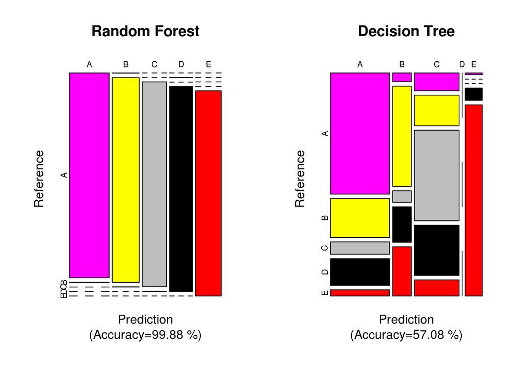

```r
par(mfrow=c(1,2))

plotcolors <- as.integer(unique(trainingset$classe)) + 5

# Plot Random Forest result
plot(cm.rf$table, col=plotcolors, main='Random Forest', sub=sprintf("(Accuracy=%.2f %%)", cm.rf$overall['Accuracy']*100))

# Plot Decision Tree result
plot(cm.dt$table, col=plotcolors, main='Decision Tree', sub=sprintf("(Accuracy=%.2f %%)", cm.dt$overall['Accuracy']*100))
```

#### D. Generating Submission File

```r
# File Generation Function -- provided in Coursera
pml_write_files = function(x){
  n = length(x)
  for(i in 1:n){
    filename = paste0("problem_id_",i,".txt")
    write.table(x[i],file=filename,quote=FALSE,row.names=FALSE,col.names=FALSE)
  }
}

# Read Test Dataset
testingset <- read.csv('./dataset/pml-testing.csv', na.strings=c('','NA','#DIV/0!'))

# Select the same variables/columns as predictors
n <- names(trainingset.train)
testingset <- testingset[, n[n!='classe'] ]

# Apply Random Forest Model
testingset.result <- predict(model.rf, newdata=testingset)
testingset.result
```

```
##  [1] B A B A A E D B A A B C B A E E A B B B
## Levels: A B C D E
```

```r
# Generate answer files
pml_write_files(testingset.result)
```